# RRBS Methylation Procedure in R

Author: Emily Swanzey

August 8, 2017

# Initilization

## Environments

- [Custom Code (Github Repository)](https://github.com/RobertSellers/R_mm10AA)
- [methylKit](https://bioconductor.org/packages/release/bioc/html/methylKit.html)
- [complexHeatmap](https://bioconductor.org/packages/release/bioc/html/ComplexHeatmap.html)
- [genomation](https://bioconductor.org/packages/release/bioc/html/ComplexHeatmap.html)
- [ggbio](https://bioconductor.org/packages/release/bioc/html/ggbio.html)
- [BSgenome.Mmusculus.UCSC.mm10.masked](https://bioconductor.org/packages/release/data/annotation/html/BSgenome.Mmusculus.UCSC.mm10.masked.html)
- [GenomicRanges](https://bioconductor.org/packages/release/bioc/html/GenomicRanges.html)

```r
#setwd("~/Desktop/R_mm10AA copy")
source('scripts/environments.R'); loadWorkspace()
source('scripts/visualizations.R')
source('scripts/custom_functions.R')
```

## Complementary data files

- RefSeqGenesmm10.bed: https://genome.ucsc.edu/
- CpGislandmm10.bed: https://genome.ucsc.edu/
- refGene.txt: http://hgdownload.cse.ucsc.edu/goldenPath/mm10/
- GSM2071581_ENCFF226NCD_transcript_quantifications_mm10.tsv: https://www.ncbi.nlm.nih.gov/geo/query/acc.cgi?acc=GSM2071581

Using **readTranscriptFeatures** and **readFeatureFlank** functions from the *genomation* library, the gene and flank data are loaded (be more specific), respectively.

```r
gene.parts = readTranscriptFeatures("bed/RefSeqGenesmm10.bed")
refGenome = read.table("bed/refGene.txt", sep="\t")
cpg.obj = readFeatureFlank("bed/CpGislandmm10.bed", feature.flank.name = c("CpGi","shores"))
#Load
rna.seq.mm10 <-read.table(file = 'bed/GSM2071581_ENCFF226NCD_transcript_quantifications_mm10.tsv', sep = '\t', header = TRUE)
```

## Loading the experiment

The following code uses **methRead** function to construct male, female, and all **methylRaw** objects for analysis.

```r
male.control <- list("test1","test2","test3","ctrl7","ctrl8","ctrl9")
female.control <- list("test4","test5","test6","ctrl10","ctrl11","ctrl12")
all.control <- append(male.control, female.control)

plus.minus.split <- c(1,1,1,0,0,0)
plus.minus.all <- c(1,1,1,0,0,0,1,1,1,0,0,0)

male.file.list <- list("data/cpg_MS1_mincov10.txt","data/cpg_MS2_mincov10.txt","data/cpg_MS3_mincov10.txt","data/cpg_MS7_mincov10.txt","data/cpg_MS8_mincov10.txt","data/cpg_MS9_mincov10.txt")

female.file.list <- list("data/cpg_MS4_mincov10.txt","data/cpg_MS5_mincov10.txt","data/cpg_MS6_mincov10.txt","data/cpg_MS10_mincov10.txt","data/cpg_MS11_mincov10.txt","data/cpg_MS12_mincov10.txt")

all.file.list <- append(male.file.list, female.file.list)

destfile <- "./save/male.rds"
if(!file.exists(destfile)){
  male <- methRead(male.file.list, sample.id=male.control, assembly="mm10", treatment=plus.minus.split, context="CpG")
  saveRDS(male, destfile)
}else{
  male<-readRDS(destfile)
}

destfile <- "./save/female.rds"
if(!file.exists(destfile)){
  female <- methRead(female.file.list, sample.id=female.control, assembly="mm10", treatment=plus.minus.split, context="CpG")
  saveRDS(female, destfile)
}else{
  female<-readRDS(destfile)
}

destfile <- "./save/all.rds"
if(!file.exists(destfile)){
  all <- methRead(all.file.list, sample.id=all.control, assembly="mm10", treatment=plus.minus.all, context="CpG")
  saveRDS(all, destfile)
}else{
  all<-readRDS(destfile)
}

rm(male.control, female.control, all.control, plus.minus.split, male.file.list, female.file.list, all.file.list)
```

The treatment sequence on all is 1, 1, 1, 0, 0, 0, 1, 1, 1, 0, 0, 0. The resulting dimensions for all are 1300434, 7

## Configuring genome sequences

Utilizing the *BSgenome.Mmusculus.UCSC.mm10* package to extract the Full genome sequences for Mus musculus (Mouse) as provided by UCSC (mm10, Dec. 2011) and stored in Biostrings objects. This is especially useful for the ideograms.

```r
chr.len <- seqlengths(Mmusculus)
chr.len <- chr.len[grep("_|M", names(chr.len), invert = T)]
```

## Quality Control

### % CpG Methylation

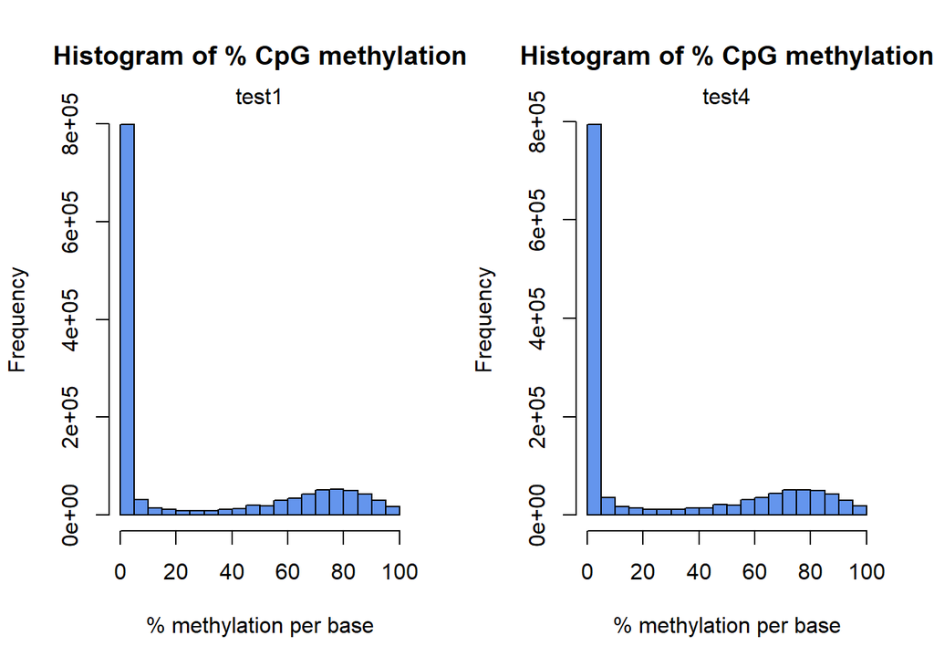

```r
par(mfrow=c(1,2))
getMethylationStats(all[[1]], plot=T, both.strands = F, labels = FALSE)
getMethylationStats(all[[7]], plot=T, both.strands = F, labels = FALSE)
```

### CpG coverage

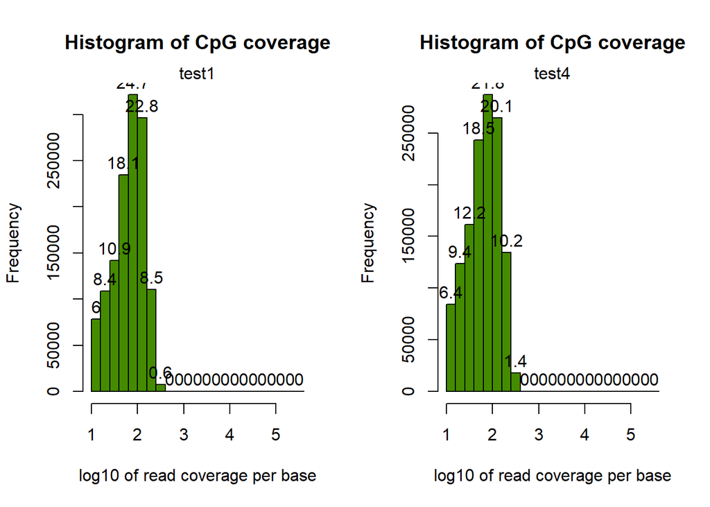

```r
par(mfrow=c(1,2))
getCoverageStats(all[[1]], plot=T, both.strands = F, labels = TRUE)
getCoverageStats(all[[7]], plot=T, both.strands = F, labels = TRUE)
```

# Data Processing

## Filter and Normalize Samples

Using **filterByCoverage**, we filter samples based on coverage and discards bases with coverage below 10x and also discards bases that have more than 99.9th percentile of coverage in each sample. Furthermore, using **normalizeCoverage** we normalize coverage to reduce statistical bias. Please follow [this link](https://github.com/RobertSellers/R_mm10AA/blob/master/scripts/custom_functions.R) to view the function contents.

```r
male.filt.norm <- filterAndNormalize(male, 10, 99.9)
female.filt.norm <- filterAndNormalize(female, 10, 99.9)
all.filt.norm <- filterAndNormalize(all, 10, 99.9)
```

## Merge Samples

Using **unite**, we merge all samples into one object for base-pair locations that are covered in all samples. Please follow [this link](https://github.com/RobertSellers/R_mm10AA/blob/master/scripts/custom_functions.R) to view the function contents.

```r
male.filt.norm.meth <- mergeAndMethylate(male.filt.norm)
female.filt.norm.meth <- mergeAndMethylate(female.filt.norm)
all.filt.norm.meth <- mergeAndMethylate(all.filt.norm)
```

# Statistical Analysis

## Correlation

Using **getCorrelation** we return a matrix of correlation coefficients.

```r
getCorrelation(all.filt.norm.meth, plot=F)
```

```
##            test1     test2     test3     ctrl7     ctrl8     ctrl9
## test1  1.0000000 0.9728426 0.9804975 0.9549624 0.9722236 0.9712634
## test2  0.9728426 1.0000000 0.9754161 0.9503191 0.9673832 0.9663820
## test3  0.9804975 0.9754161 1.0000000 0.9577886 0.9751125 0.9743493
## ctrl7  0.9549624 0.9503191 0.9577886 1.0000000 0.9572532 0.9561550
## ctrl8  0.9722236 0.9673832 0.9751125 0.9572532 1.0000000 0.9736216
## ctrl9  0.9712634 0.9663820 0.9743493 0.9561550 0.9736216 1.0000000
## test4  0.9740816 0.9691492 0.9766197 0.9513334 0.9684180 0.9674995
## test5  0.9733494 0.9683361 0.9759743 0.9505418 0.9674401 0.9667077
## test6  0.9603472 0.9556886 0.9629089 0.9379700 0.9548397 0.9541149
## ctrl10 0.9714795 0.9665756 0.9742666 0.9568151 0.9737779 0.9727139
## ctrl11 0.9737340 0.9688375 0.9767899 0.9581512 0.9757499 0.9749752
## ctrl12 0.9711250 0.9661497 0.9739340 0.9558449 0.9733471 0.9722754
##            test4     test5     test6    ctrl10    ctrl11    ctrl12
## test1  0.9740816 0.9733494 0.9603472 0.9714795 0.9737340 0.9711250
## test2  0.9691492 0.9683361 0.9556886 0.9665756 0.9688375 0.9661497
## test3  0.9766197 0.9759743 0.9629089 0.9742666 0.9767899 0.9739340
## ctrl7  0.9513334 0.9505418 0.9379700 0.9568151 0.9581512 0.9558449
## ctrl8  0.9684180 0.9674401 0.9548397 0.9737779 0.9757499 0.9733471
## ctrl9  0.9674995 0.9667077 0.9541149 0.9727139 0.9749752 0.9722754
## test4  1.0000000 0.9743963 0.9612350 0.9721021 0.9746734 0.9720198
## test5  0.9743963 1.0000000 0.9607185 0.9713160 0.9740005 0.9712797
## test6  0.9612350 0.9607185 1.0000000 0.9584560 0.9608821 0.9584382
## ctrl10 0.9721021 0.9713160 0.9584560 1.0000000 0.9794856 0.9773195
## ctrl11 0.9746734 0.9740005 0.9608821 0.9794856 1.0000000 0.9794811
## ctrl12 0.9720198 0.9712797 0.9584382 0.9773195 0.9794811 1.0000000
```

## Hierarchical clustering

Using **clusterSamples** we return a matrix of correlation coefficients using the **hclust** function “and various distance metrics derived from percent methylation per base or per region for each sample”.

```
## The "ward" method has been renamed to "ward.D"; note new "ward.D2"
```

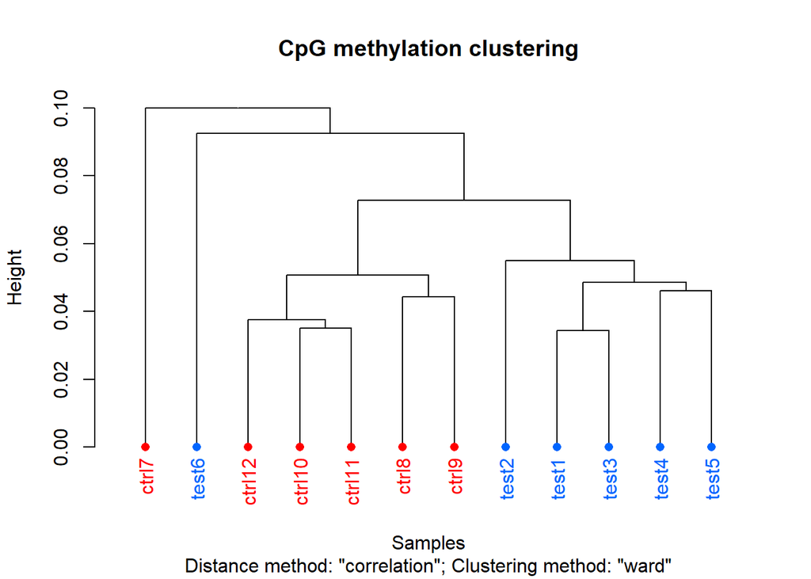

```
##
## Call:
## hclust(d = d, method = HCLUST.METHODS[hclust.method])
##
## Cluster method   : ward.D
## Distance         : pearson
## Number of objects: 12
```

```r
clusterSamples(all.filt.norm.meth,dist="correlation", method="ward",plot=TRUE)
```

## PCA Analysis

The **PCASamples** does a PCA analysis using the **prcomp** function using percent methylation matrix as an input.

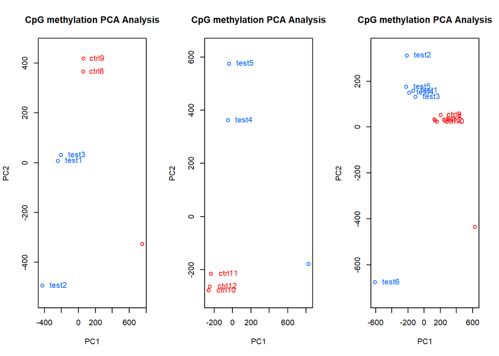

```r
par(mfrow=c(1,3))
PCASamples(male.filt.norm.meth)
PCASamples(female.filt.norm.meth)
PCASamples(all.filt.norm.meth)
```

# Differential methylation method

To be compared with the upcoming Window Method, the differential methylation method initially utilizes the **calculateDiffMeth** from *methylKit* which calculates differential methylation statistics between two groups of samples. The following perhaps this function on our united & base-paired samples. Furthermore, the **getMethylDiff** function is performed per gender at varying methylation thresholds. Please follow [this link](https://github.com/RobertSellers/R_mm10AA/blob/master/scripts/custom_functions.R) to view the function contents.

Visualizations include the distribution of hypo/hyper-methylated bases/regions per chromosome if plot=FALSE, it will show a list per chromosome differentially methylated events will be returned.

## Male

```r
par(mfrow=c(1,2))
seqVals.male <- suppressWarnings(diffMethSequence(male.filt.norm.meth, 0.01))
```

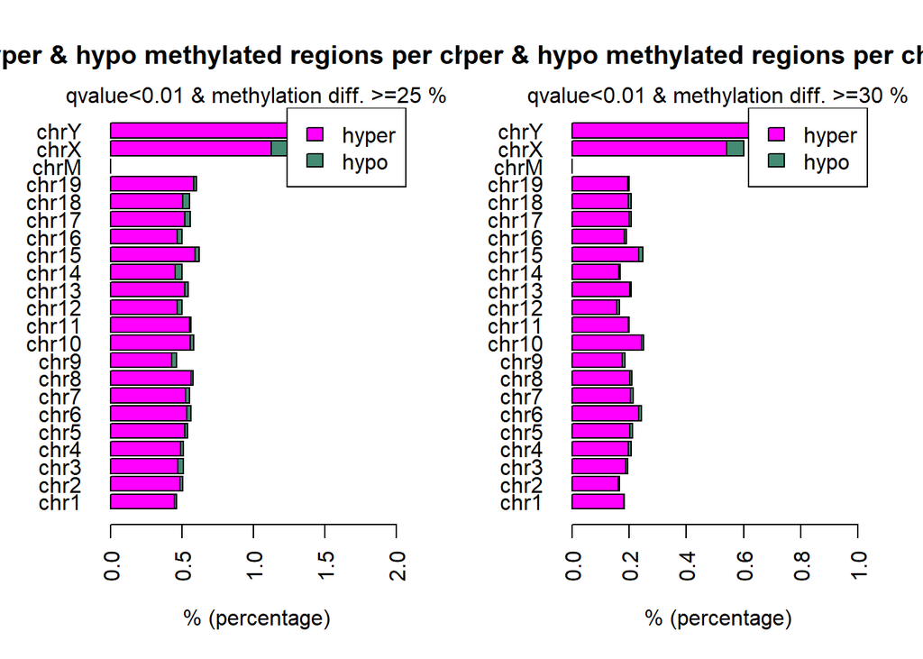

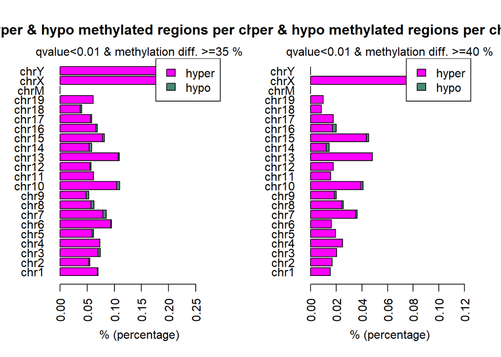

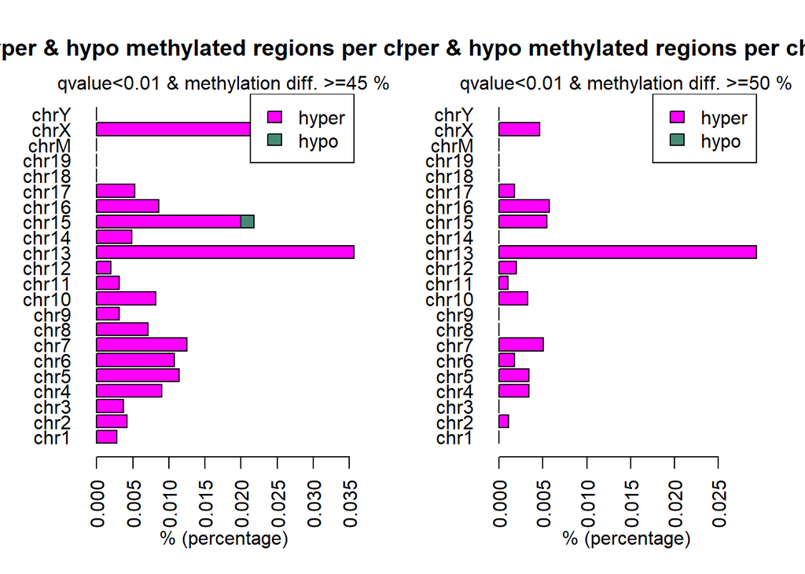

## Female

```r
par(mfrow=c(1,2))
seqVals.female <- suppressWarnings(diffMethSequence(female.filt.norm.meth, 0.01))
```

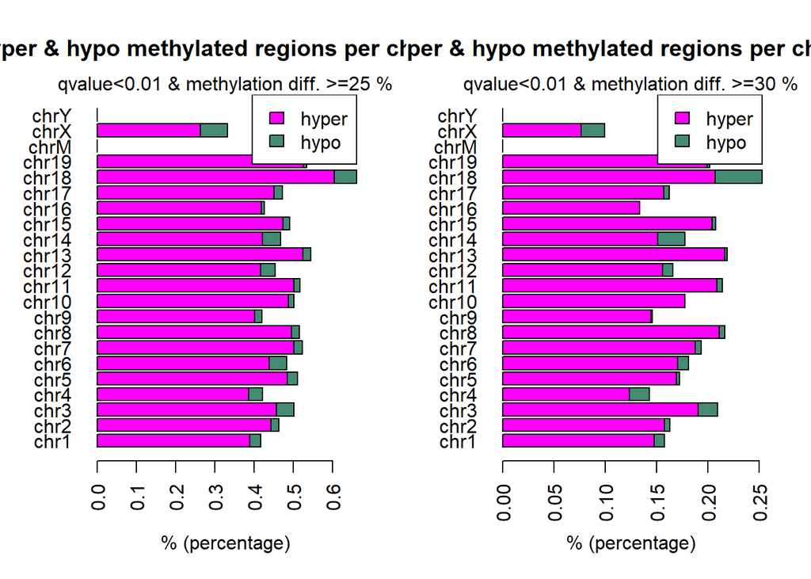

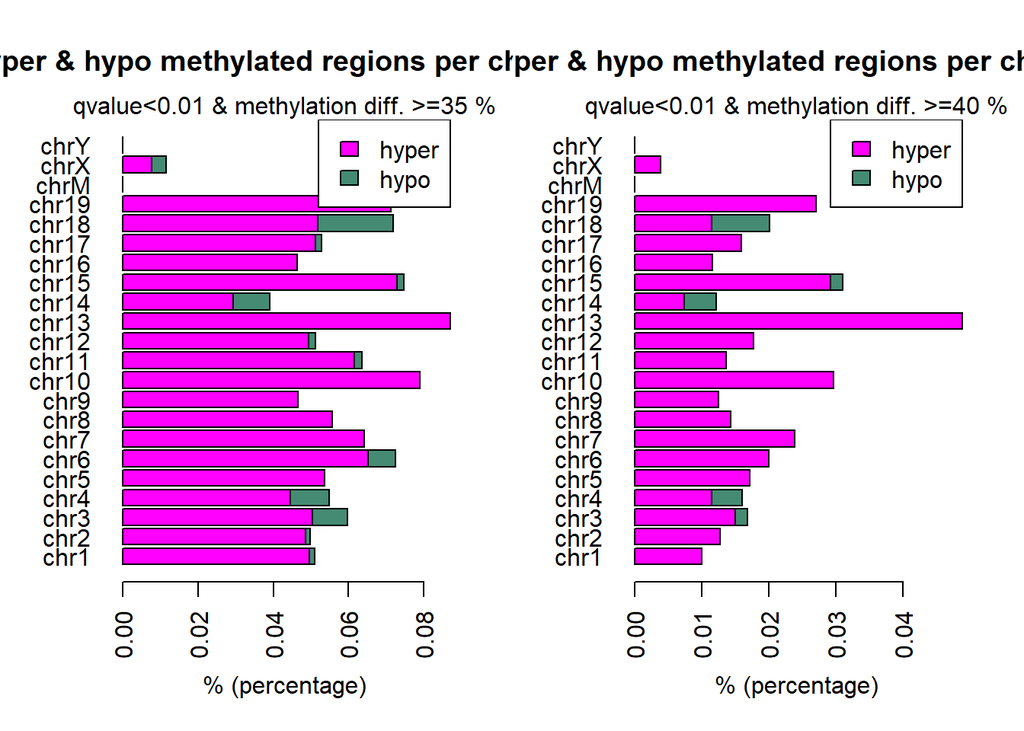

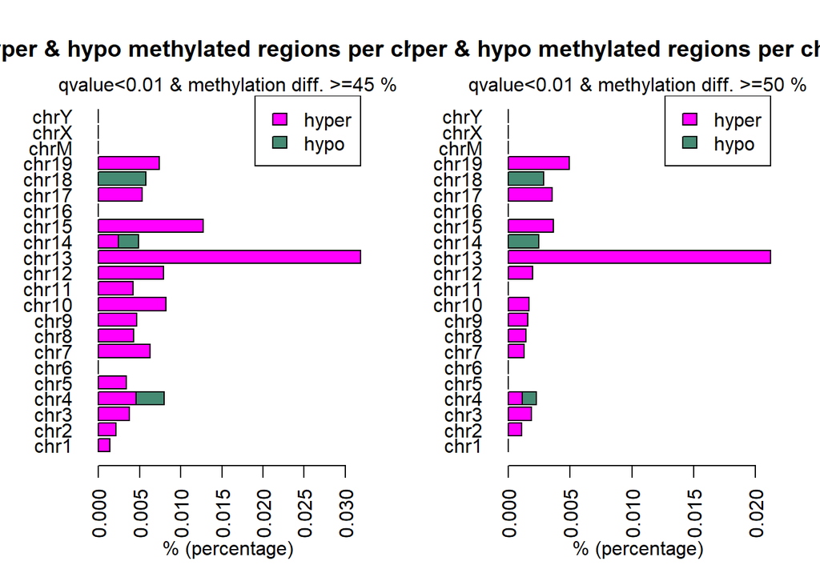

## All

```r
par(mfrow=c(1,2))
seqVals.all <- suppressWarnings(diffMethSequence(all.filt.norm.meth, 0.01))
```

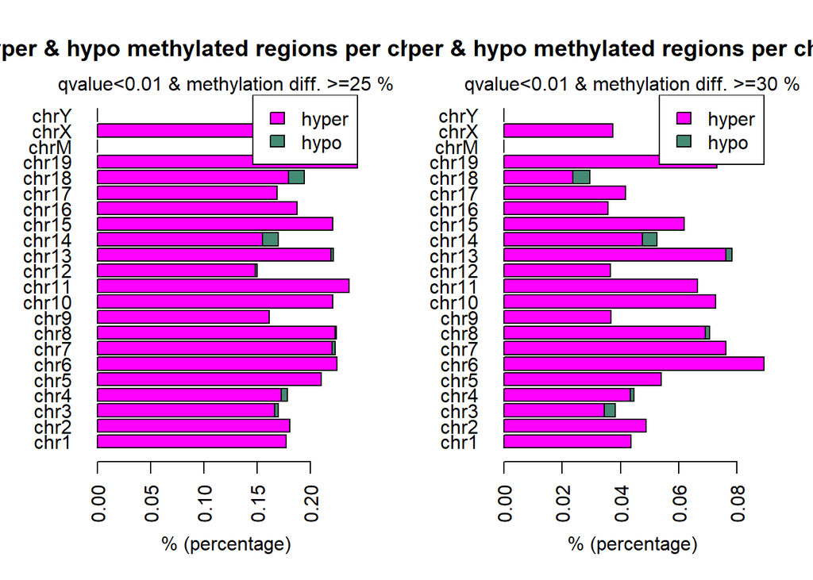

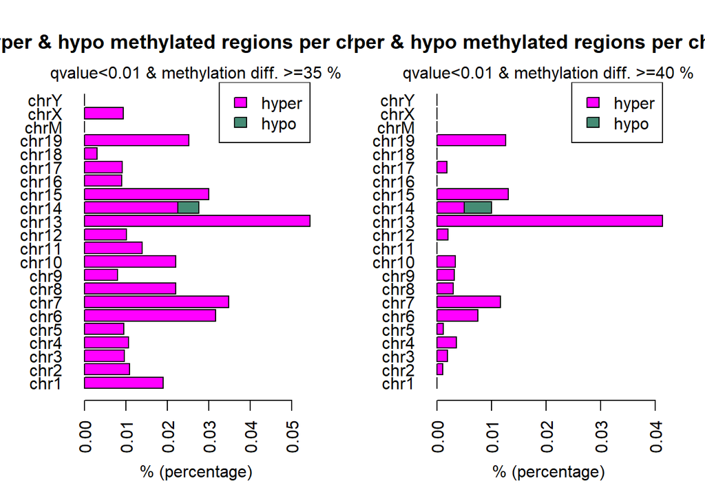

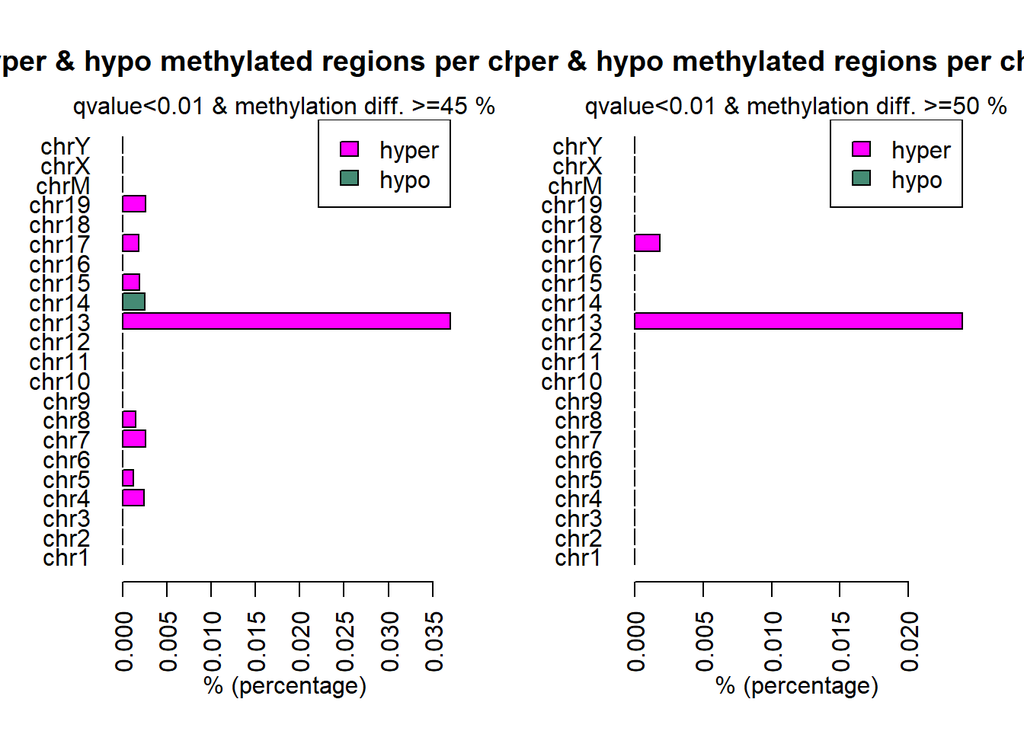

## Idiogram comparison

Using **layout_circle** function with *ggbio* and *ggplot2* packages, we can display the idiograms per group. Please follow [this link](https://github.com/RobertSellers/R_mm10AA/blob/master/scripts/custom_functions.R) to view the function contents.

### Male

```r
suppressWarnings(ideoDMC(seqVals.male$diff,chr.len,difference=30,qvalue = 0.01,
        title = "Differential bases > 30%", hyper.col = "magenta",hypo.col = "green"))
```

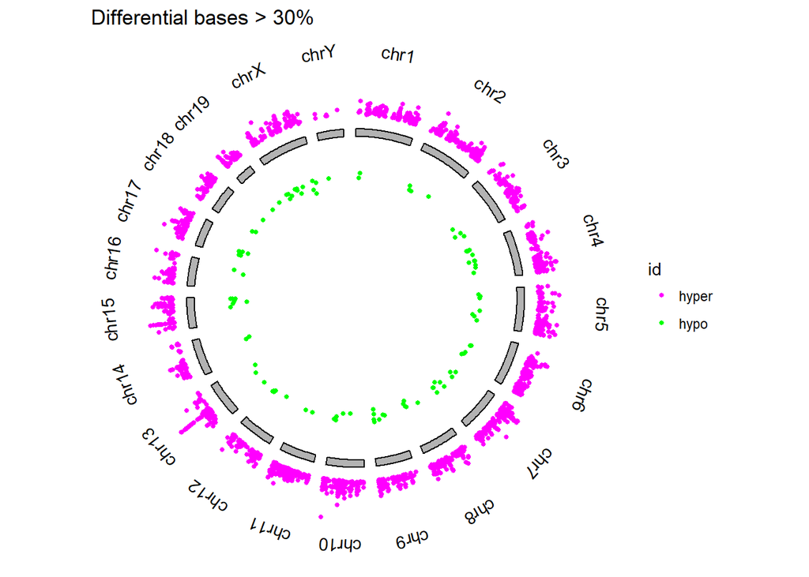

### Female

```r
suppressWarnings(ideoDMC(seqVals.female$diff,chr.len,difference=30,qvalue = 0.01,
        title = "Differential bases > 30%", hyper.col = "magenta",hypo.col = "green"))
```

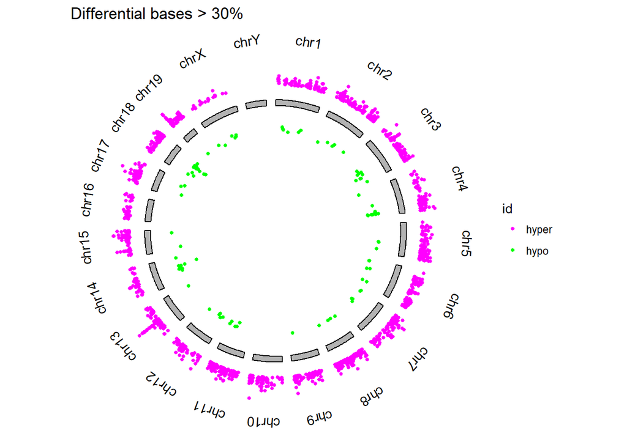

### All

```r
suppressWarnings(ideoDMC(seqVals.all$diff,chr.len,difference=30,qvalue = 0.01,
        title = "Differential bases > 30%", hyper.col = "magenta",hypo.col = "green"))
```

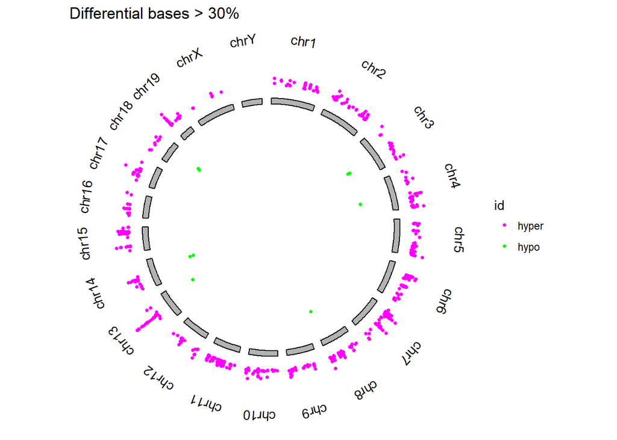

## Annotation and CpG island

Using **annotateWithGeneParts**, **getTargetAnnotationStats**, & **plotTargetAnnotation** functions of the *genomation* package, we can annotate. Please follow [this link](https://github.com/RobertSellers/R_mm10AA/blob/master/scripts/custom_functions.R) to view the function contents.

### Male

```r
par(mfrow=c(2,2))
#25 & 50 male
suppressWarnings(annotateRefSymbol(seqVals.male$diffs$diff25p, gene.parts, cpg.obj,25))
```

```
## intersecting chromosomes...
```

```r
suppressWarnings(annotateRefSymbol(seqVals.male$diffs$diff50p, gene.parts, cpg.obj,50))
```

```
## intersecting chromosomes...
```

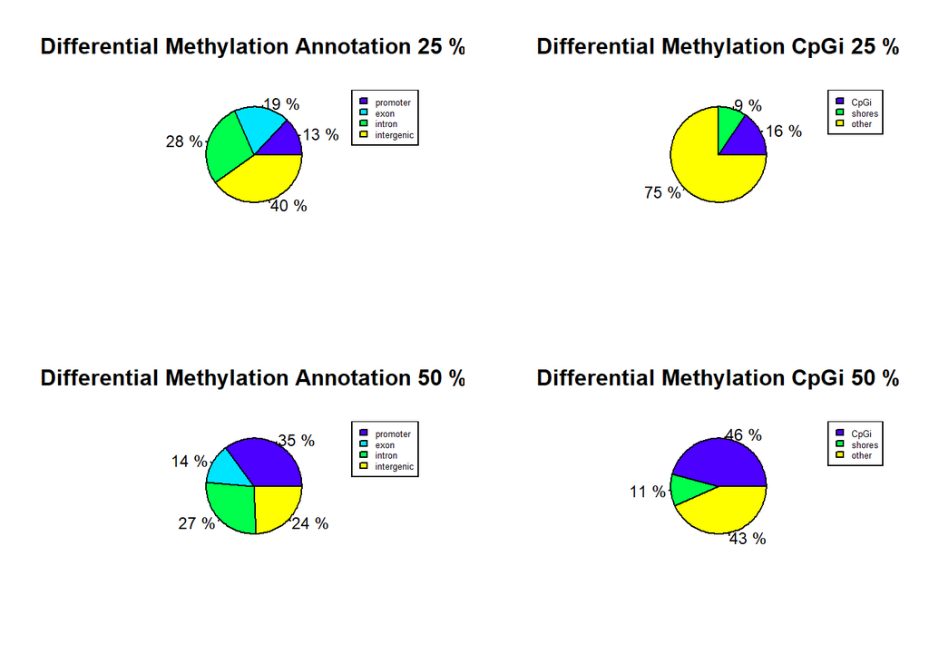

### Female

```r
par(mfrow=c(2, 2))
#25 & 50 female
suppressWarnings(annotateRefSymbol(seqVals.female$diffs$diff25p, gene.parts, cpg.obj, 25))
```

```
## intersecting chromosomes...
```

```r
suppressWarnings(annotateRefSymbol(seqVals.female$diffs$diff50p, gene.parts, cpg.obj, 50))
```

```
## intersecting chromosomes...
```

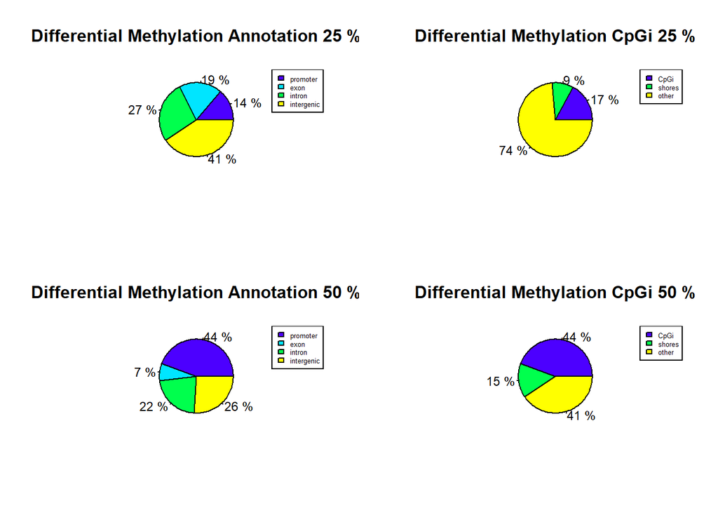

### All

```r
par(mfrow=c(2,2))
#25 & 50 all
suppressWarnings(annotateRefSymbol(seqVals.all$diffs$diff25p, gene.parts, cpg.obj, 25))
```

```
## intersecting chromosomes...
```

```r
suppressWarnings(annotateRefSymbol(seqVals.all$diffs$diff50p, gene.parts, cpg.obj, 50))
```

```
## intersecting chromosomes...
```

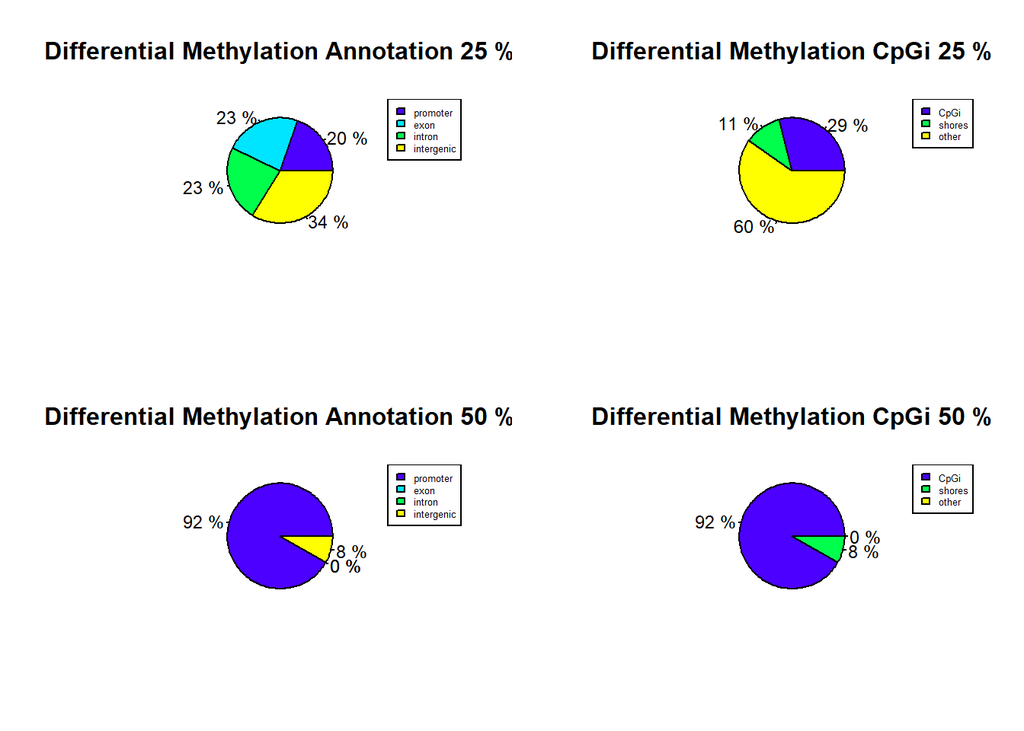

```r
suppressWarnings(annotateRefSymbol(seqVals.all$diff, gene.parts, cpg.obj, 0))
```

```
## intersecting chromosomes...
```

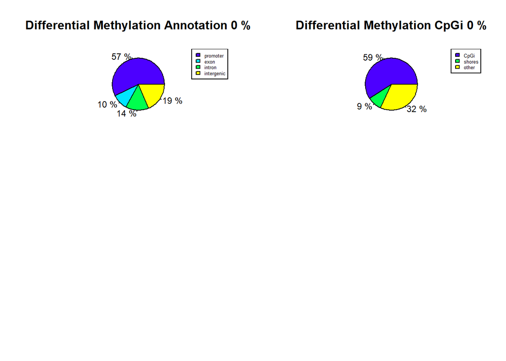

# More Annotation

```r
#Summarize methylation over all CpGi's
#CpGi.counts = regionCounts(seqVals.all$diff, gene.parts$CpGi)

#goldmineAnno = goldmine(tiles.all, genes=getGenes(geneset="ucsc", genome=genome, cachedir=cachedir), features=list(), promoter=c(1000,500), end3=c(1000,1000), contextonly=FALSE, genome, cachedir, sync=TRUE)
```

# Window Approach

Input parameters are the 1. Window Size, 2. Step Size, 3. Bases Covered, 4. difference, 5. q value.

Also outputs text files and plots *methylKit’s* **diffMethPerChr** output.

```r
tiles.male <- customWindowMethod(male.filt.norm, 500, 50, 5, 25, 0.01, gene.parts)
```

```
## intersecting chromosomes...
```

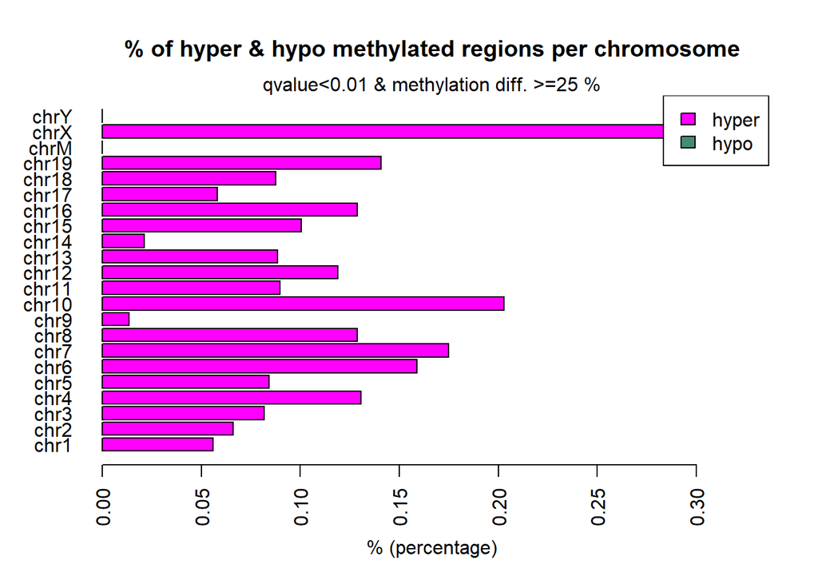

```r
tiles.female <- customWindowMethod(female.filt.norm, 500, 50, 5, 25, 0.01, gene.parts)
```

```
## intersecting chromosomes...
```

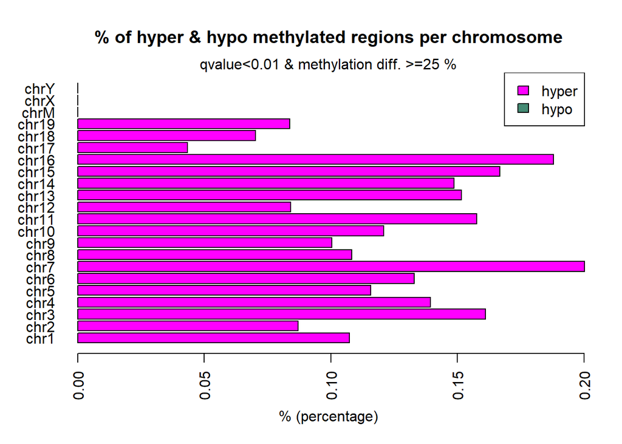

```r
tiles.all <- customWindowMethod(all.filt.norm, 500, 50, 5, 25, 0.01, gene.parts)
```

```
## intersecting chromosomes...
```

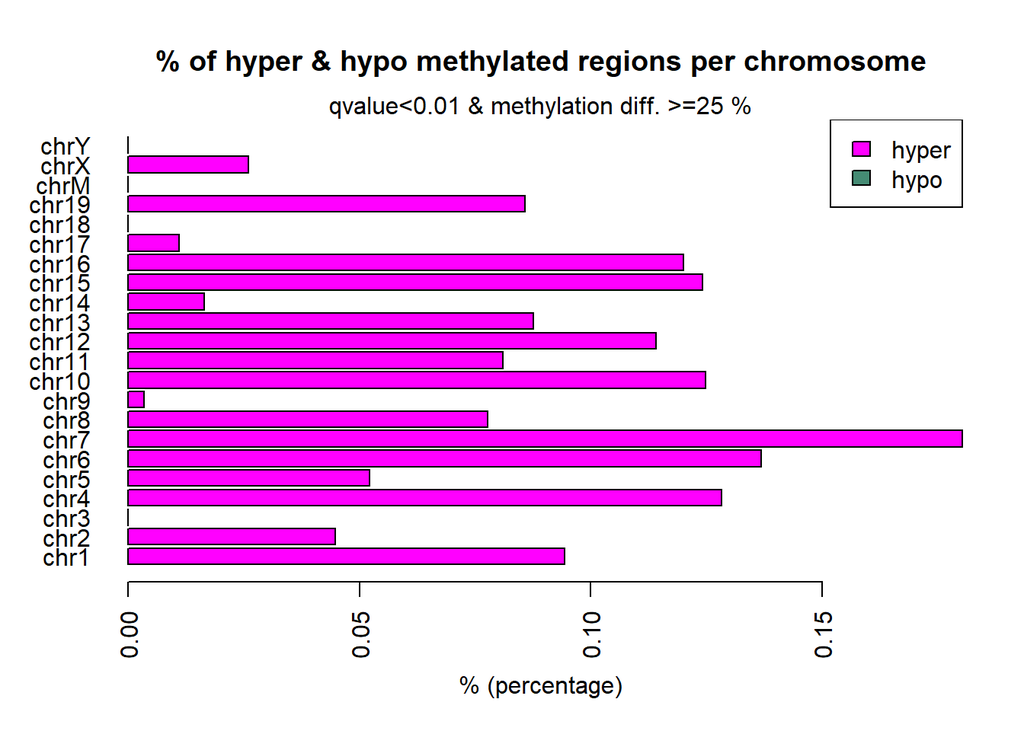

# Merge and trim windows

## this needs figuring out - the numbers don’t quite make sense

```r
#Merge to get one range per gene - this isn't quite right (need continuous ranges)
df.gene.interval.anno <- cbind(tiles.all$gene.lookup, tiles.all$diffMeth.percent)
minJoin <- aggregate(start ~ feature.name + chr, df.gene.interval.anno, min)
maxJoin <- aggregate(end ~ feature.name + chr, df.gene.interval.anno, max)
lookup.tile.ranges25p <- merge(minJoin, maxJoin)


#calculate windows again
# %CpG methylation per region
my.win.tile25p.gr <- GRanges(
  seqnames = lookup.tile.ranges25p$chr,
  ranges = IRanges(start = lookup.tile.ranges25p$start, end = lookup.tile.ranges25p$end))
my.win.tile.25p.methylRaw = regionCounts(object = all.filt.norm, regions = my.win.tile25p.gr, cov.bases = 0, strand.aware=TRUE)
my.win.tile.25p.unite = unite(my.win.tile.25p.methylRaw)
#stats = getMethylationStats(my.win.tild.25p.unite)

#Differential methylation per region
```

### Window annotation (all)

```r
#par(mfrow=c(2,2))
#25 & 50 all

#suppressWarnings(annotateRefSymbol(tiles.all$diffMeth, gene.parts, cpg.obj, 25))
```

## Circos Idiogram

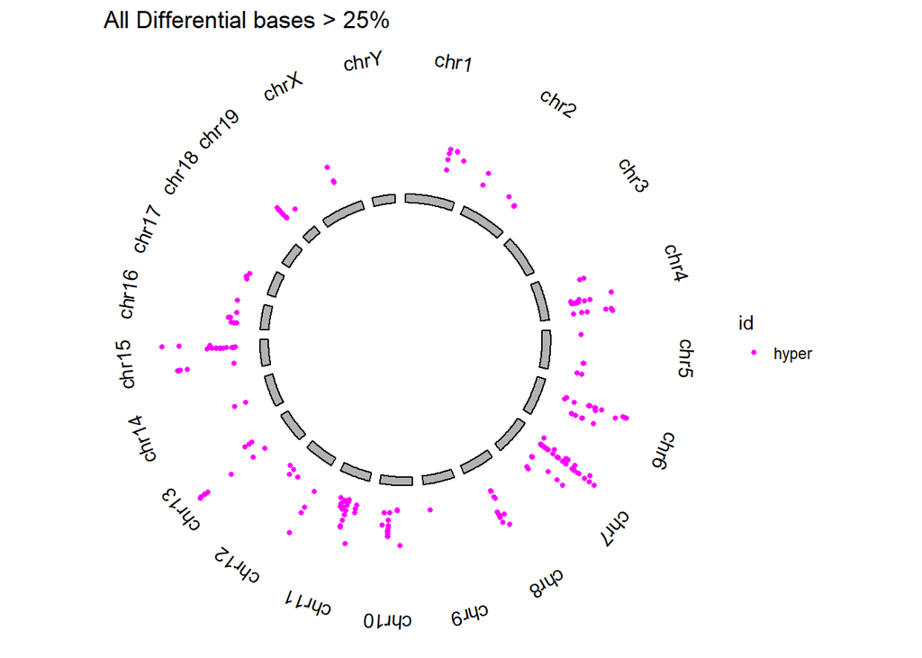

```r
#All
ideoDMC(tiles.all$diffMeth, chr.len, difference = 25,qvalue = 0.01,
        title = "All Differential bases > 25%", hyper.col = "magenta",hypo.col = "green")
```

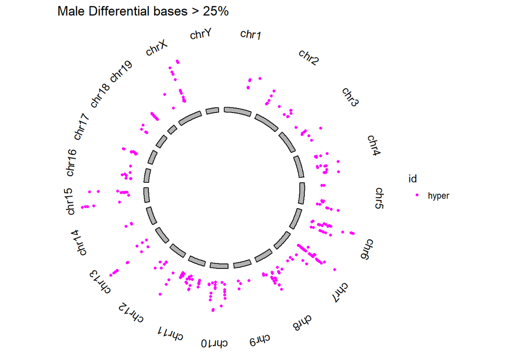

```r
#Male
ideoDMC(tiles.male$diffMeth, chr.len, difference = 25, qvalue = 0.01,
        title = "Male Differential bases > 25%", hyper.col = "magenta",hypo.col = "green")
```

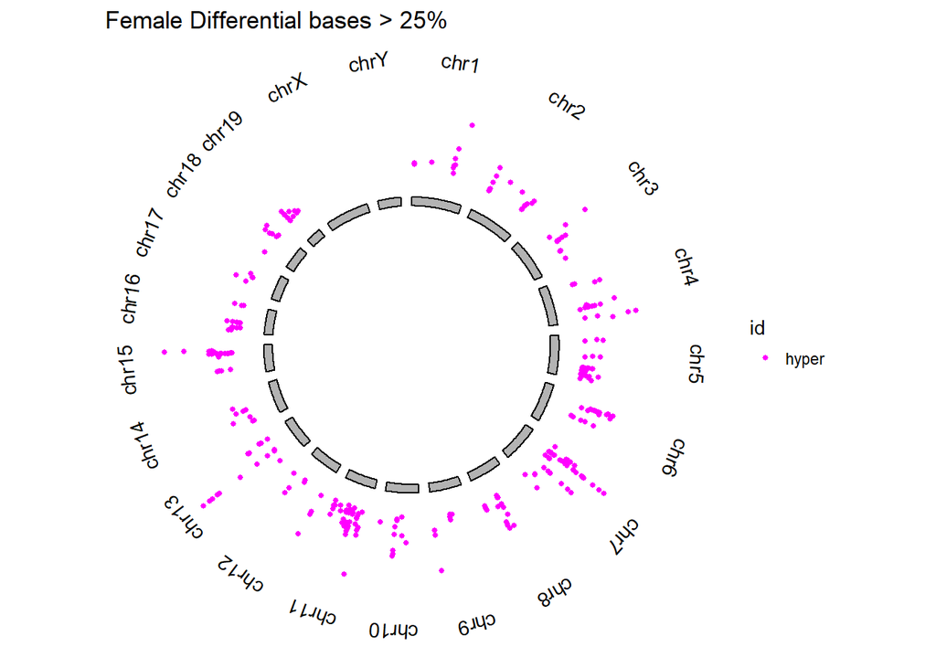

```r
#Female
ideoDMC(tiles.female$diffMeth, chr.len, difference = 25, qvalue = 0.01,
        title = "Female Differential bases > 25%", hyper.col = "magenta",hypo.col = "green")
```

```r
# histone stuff


#require(org.Mmu.eg.db)
#require(TxDb.Mmusculus.UCSC.mm10.knownGene)
#txdb <- TxDb.Mmusculus.UCSC.mm10.knownGene
# loading H3K4me1 peaks as a GRanges object
# built based on the BED file from the GEO GSM1234488 sample
# Peak = Point-source called for this peak; 0-based offset from Start. Set to -1 if no point-source called
#enh <- compEpiTools::enhancers(H3K4me1GR, txdb)
#m.enh <- matchEnhancers(enhGR = enh, minD = 2e4, maxD=2e5, txdb = txdb, EG2GS = org.Mmu.eg.db)

file.list <- c( "bed/H3K4me1.bed", "bed/H3K9me3.bed", "bed/H3K4me2.bed", "bed/H3K4me3.bed", "bed/H3K9ac.bed", "bed/H3K27ac.bed", "bed/H3K27me3.bed", "bed/H3K36me3.bed")

histone.intersections <- list()
gr2 <- makeGRangesFromDataFrame(lookup.tile.ranges25p)

for (i in 1:length(file.list))
{
  histoneMarks <- read.table(file.list[i])
  colnames(histoneMarks) <- c('chr', 'start', 'end', 'name', 'score','strand', "signalValue", "pValue", "qValue", "peak")
  GRi <- makeGRangesFromDataFrame(histoneMarks)
  histone.intersections[i] <- intersect(GRi, gr2, ignore.strand = TRUE)
}
print(histone.intersections)
```

```
## [[1]]
## GRanges object with 38 ranges and 0 metadata columns:
##        seqnames                 ranges strand
##           <Rle>              <IRanges>  <Rle>
##    [1]     chr1 [133889651, 133890600]      *
##    [2]     chr1 [155028801, 155029750]      *
##    [3]     chr1 [180829901, 180830750]      *
##    [4]     chr2 [122349101, 122349850]      *
##    [5]     chr2 [154551956, 154552500]      *
##    ...      ...                    ...    ...
##   [34]    chr14   [55761784, 55762200]      *
##   [35]    chr15   [76666501, 76667750]      *
##   [36]    chr15   [77858001, 77858328]      *
##   [37]    chr17   [34038601, 34039100]      *
##   [38]    chr19   [45660601, 45661150]      *
##   -------
##   seqinfo: 23 sequences from an unspecified genome; no seqlengths
##
## [[2]]
## GRanges object with 0 ranges and 0 metadata columns:
##    seqnames    ranges strand
##       <Rle> <IRanges>  <Rle>
##   -------
##   seqinfo: 38 sequences from an unspecified genome; no seqlengths
##
## [[3]]
## GRanges object with 45 ranges and 0 metadata columns:
##        seqnames                 ranges strand
##           <Rle>              <IRanges>  <Rle>
##    [1]     chr1 [133889955, 133890600]      *
##    [2]     chr1 [136695911, 136696350]      *
##    [3]     chr1 [155028801, 155029495]      *
##    [4]     chr1 [180829901, 180830750]      *
##    [5]     chr2 [122349101, 122349759]      *
##    ...      ...                    ...    ...
##   [41]    chr17 [ 34038614,  34039100]      *
##   [42]    chr17 [ 47468259,  47468600]      *
##   [43]    chr19 [  5756563,   5757311]      *
##   [44]    chr19 [ 45660601,  45661021]      *
##   [45]     chrX [102178520, 102178790]      *
```

[output cut: 69 more lines]

```
##   [20]    chr17   [47468101, 47468341]      *
##   [21]    chr19   [ 5756251,  5757062]      *
##   [22]    chr19   [ 5757102,  5757550]      *
##   -------
##   seqinfo: 22 sequences from an unspecified genome; no seqlengths
##
## [[8]]
## GRanges object with 3 ranges and 0 metadata columns:
##       seqnames               ranges strand
##          <Rle>            <IRanges>  <Rle>
##   [1]     chr8 [70331851, 70331936]      *
##   [2]     chr8 [70332033, 70332700]      *
##   [3]    chr10 [80131501, 80131738]      *
##   -------
##   seqinfo: 27 sequences from an unspecified genome; no seqlengths
```

```r
H3K4me1.tile <- makeGRangesFromDataFrame(histone.intersections[1])
H3K9me3.tile <- histone.intersections[2]
H3K4me2.tile <- histone.intersections[3]
H3K4me3.tile <- histone.intersections[4]
H3K9ac.tile <- histone.intersections[5]
H3K27ac.tile <- histone.intersections[6]
H3K27me3.tile <- histone.intersections[7]
H3K36me3.tile <- histone.intersections[8]
```

## Heatmap

Using **Heatmap** function with the *ComplexHeatmap* package, we can display the heatmap of selected methylation regions. Please follow [this link](https://github.com/RobertSellers/R_mm10AA/blob/master/scripts/custom_functions.R) to view the function contents.

```r
#Merge and create lookup gene values
#df.gene.interval.anno <- cbind(tiles.all$gene.lookup, tiles.all$diffMeth.percent)
names(refGenome)[names(refGenome) == 'V2'] <- 'feature.name'
names(refGenome)[names(refGenome) == 'V13'] <- 'geneSymbol'
df.gene.interval.anno.joined <- left_join(df.gene.interval.anno, refGenome[ , c("feature.name", "geneSymbol")], by = "feature.name", all.x = TRUE)
```

```r
#Merge data types and create a summary list. Diff meth might be incorrect. CHECK!
minJoin <- aggregate(start ~ geneSymbol + feature.name + chr, df.gene.interval.anno.joined, min)
maxJoin <- aggregate(end ~ geneSymbol + feature.name + chr, df.gene.interval.anno.joined, max)
meanDiffJoin <- aggregate(meth.diff ~ geneSymbol, df.gene.interval.anno.joined, FUN = mean)
distFeatJoin <- aggregate(dist.to.feature ~ geneSymbol, df.gene.interval.anno.joined, min)
lookup.tile.ranges <- merge(minJoin, maxJoin)
lookup.tile.ranges.Diff <- merge(lookup.tile.ranges, meanDiffJoin)
lookup.tile.ranges.Diff.dist <- merge(lookup.tile.ranges.Diff, distFeatJoin)

#find overlaps with CpGi
cpg.gr = makeGRangesFromDataFrame(cpg.obj)
gr.hits = with(lookup.tile.ranges, GRanges(chr, IRanges(start, end)))
hits.cpg.overlaps = suppressWarnings(findOverlaps(gr.hits, cpg.gr, type = c("within")))
hits.cpg.overlaps.df <- as.data.frame(hits.cpg.overlaps)
hits.with.cpgi.df <- as.data.frame(gr.hits[hits.cpg.overlaps.df$queryHits])
colnames(hits.with.cpgi.df)[1] <- "chr"
hits.with.cpgi.unique = hits.with.cpgi.df[!duplicated(hits.with.cpgi.df), ]
colnames(hits.with.cpgi.unique)[4] <- "CpGi"
hits.with.cpgi.lookup <- plyr::join(lookup.tile.ranges.Diff.dist, hits.with.cpgi.unique, by = c("chr", "start", "end"))
hits.with.cpgi.lookup[["CpGi"]][is.na(hits.with.cpgi.lookup[["CpGi"]])] <- 0

#find overlaps with histone modifications
hits.H3K4me3 = suppressWarnings(findOverlaps(gr.hits, H3K4me1.tile, type = c("within")))
hits.H3K4me3.df = as.data.frame(hits.H3K4me3)
hits.with.H3K4me3.df <- as.data.frame(gr.hits[hits.H3K4me3.df$queryHits])
colnames(hits.with.H3K4me3.df)[4] <- "H3K4me3"
colnames(hits.with.H3K4me3.df)[1] <- "chr"
hits.with.H3K4me3.lookup <- plyr::join(lookup.tile.ranges.Diff.dist, hits.with.H3K4me3.df, by = c("chr", "start", "end"))

#merge to make summary table
hits.with.cpgi.lookup$geneIndex <- row.names(hits.with.cpgi.lookup)

gr0 = with(all.filt.norm.meth, GRanges(chr, IRanges(start, end)))
gr1 = with(lookup.tile.ranges, GRanges(chr, IRanges(start, end)))
hits = findOverlaps(gr0, gr1)

hits.df<-as.data.frame(cbind(queryHits(hits),subjectHits(hits)))
colnames(hits.df) <- c("index","geneIndex")
all.filt.norm.meth$index <- row.names(all.filt.norm.meth)

hits.df.filled <- data.frame(
  index = all.filt.norm.meth$index,
  sample1 = all.filt.norm.meth$numCs1/all.filt.norm.meth$coverage1,
  sample2 = all.filt.norm.meth$numCs2/all.filt.norm.meth$coverage2,
  sample3 = all.filt.norm.meth$numCs3/all.filt.norm.meth$coverage3,
  sample4 = all.filt.norm.meth$numCs4/all.filt.norm.meth$coverage4,
  sample5 = all.filt.norm.meth$numCs5/all.filt.norm.meth$coverage5,
  sample6 = all.filt.norm.meth$numCs6/all.filt.norm.meth$coverage6,
  sample7 = all.filt.norm.meth$numCs7/all.filt.norm.meth$coverage7,
  sample8 = all.filt.norm.meth$numCs8/all.filt.norm.meth$coverage8,
  sample9 = all.filt.norm.meth$numCs9/all.filt.norm.meth$coverage9,
  sample10 = all.filt.norm.meth$numCs10/all.filt.norm.meth$coverage10,
  sample11 = all.filt.norm.meth$numCs11/all.filt.norm.meth$coverage11,
  sample12 = all.filt.norm.meth$numCs12/all.filt.norm.meth$coverage12
  )

hits.df.merged<-merge(hits.df, y = hits.df.filled, by = "index", all.x = TRUE)

hits.df.merged.avg<-hits.df.merged %>%
  group_by(geneIndex) %>%
  summarise_all(funs(mean(., na.rm = TRUE)))
hits.df.merged.summary <- merge(hits.df.merged.avg, hits.with.cpgi.lookup, by = "geneIndex", all.x = TRUE)
######################################
# generate methylation matrix
mat_meth <- data.matrix(hits.df.merged.summary[2:ncol(hits.df.merged.avg)])[,-1]
diffmat_meth <- data.matrix(hits.df.merged.summary$meth.diff)
distmat_meth <- data.matrix(hits.df.merged.summary$dist.to.feature)
CpGimat_meth <- data.matrix(hits.df.merged.summary$CpGi)
```

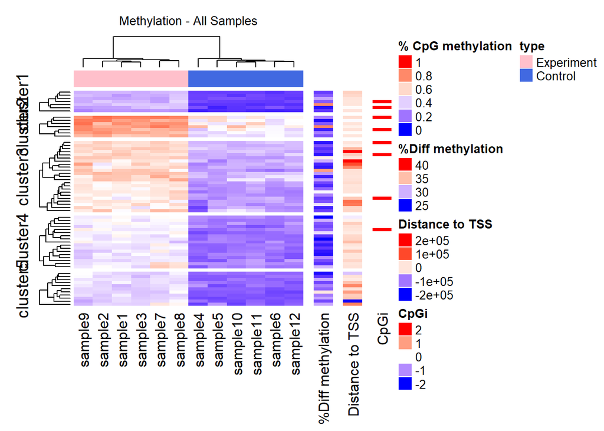

```r
res_list <- heatmapMatrixConstruction(mat_meth, plus.minus.all, lookup.tile.ranges, TRUE)
res_list2 <- heatmapMatrixConstruction(diffmat_meth, 1, lookup.tile.ranges, FALSE)
res_list3 <- heatmapMatrixConstruction(distmat_meth, 1, lookup.tile.ranges, FALSE)
res_list4 <- heatmapMatrixConstruction(CpGimat_meth, 1, lookup.tile.ranges, FALSE)

rownames(CpGimat_meth) = data.matrix(hits.df.merged.summary$geneSymbol)

par(mfrow=c(1,2))
colorRange <- c(0,0.5,1)
colorRange2 <- c(25,32.5,40)
colorRange3 <- c(-156000,-19000,118000)
colorRange4 <- c(-2, 0, 2)

#heatmap_legend_param = list(title = "Heatmap2", title_gp = gpar(fontsize = 8), labels_gp = gpar(fontsize = 14), row_names_gp = gpar(fontsize = 10))

ht_list = methylationHeatmap(res_list, "Methylation - All Samples", "% CpG methylation", TRUE, colorRange)   +
methylationHeatmap(res_list2, "", "%Diff methylation", FALSE, colorRange2) + methylationHeatmap(res_list3, "", "Distance to TSS", FALSE, colorRange3) + methylationHeatmap(res_list4, "", "CpGi", FALSE, colorRange4)
ht_list
```

```r
#iDMR.data = read.csv("bed/imprinted_dmr_test.csv")

#my.win <- GRanges(
#  seqnames = iDMR.data$Chr,
#  ranges = IRanges(start = iDMR.data$Start, width = iDMR.data$Width))

#all.regional.methylRaw = regionCounts(object = all.filt.norm.meth, regions = my.win, cov.bases = 0, strand.aware=FALSE)

#windiffmeth = calculateDiffMeth(all.regional.methylRaw)
```

# Sources

```r
# citation("org.Mmu.eg.db")
# citation("ggbio")
#
# citEntry(
#    entry="article",
#    title = "Complex heatmaps reveal patterns and correlations in multidimensional genomic data",
#    author = personList(as.person("Zuguang Gu"),
#                        as.person("Roland Eils"),
#                        as.person("Matthias Schlesner")),
#    journal = "Bioinformatics",
#    year = 2016,
#    textVersion = "Gu, Z. (2016) Complex heatmaps reveal patterns and correlations in multidimensional genomic data. Bioinformatics."
# )
#
# citFooter("This free open-source software implements academic
# research by the authors and co-workers. If you use it,
# please support the project by citing the appropriate
# journal articles.")
```